# Estudio de anomalías de temperaturas medias mensuales al norte de los 40°S

Versión 3

2026-10-09

# 1 Introducción

Esta es la **Versión 3** del proyecto de estudio de anomalías al norte de los 40°S (**ATMM40sV3**). Tiene por objetivo la creación de datos reticulados de anomalías a nivel mensual de la temperatura mínima diaria media y la temperatura máxima diaria media desde enero de 1966 en la zona continental de Argentina ubicada al norte de los 40°S, con el posterior cálculo de anomalías medias ponderadas para esta región.

- **Período bajo estudio**: Desde enero de 1966 al presente.
- **Región bajo estudio**: Argentina, al norte de los 40°S. Zona continental con una altura media sobre el nivel del mar igual o inferior a los 2000 m.
- **Resolución**: 0.5° x 0.5°.
- **Datos utilizados**: Se utilizan datos diarios de temperatura mínima y temperatura máxima de estaciones oficiales del SMN y del INTA, listadas en la Tabla 1. Quedan excluidas aquellas con una fuerte influencia de la isla de calor urbana (principalmente las del Área Metropolitana de Buenos Aires).
- **Período de referencia**: 1991-2020.

La tarea se divide en diferentes etapas:

- Pre-procesamiento de las series diarias
- Obtención de medias mensuales
- Obtención de valores normales
- Generación de los datos reticulados
- Cálculo de las anomalías medias ponderadas

# 2 **Series diarias**

## 2.1 Descripción

Las estaciones meteorológicas del SMN y del INTA que conforman el estudio se listan en la Tabla 1. Por lo general se han evitado aquellas series que de antemano se sabe que poseen una fuerte influencia de la isla de calor urbana (por ejemplo, Buenos Aires Observatorio Central, Córdoba Observatorio, Aeroparque). Esto no quiere decir que las series seleccionadas no tengan este efecto en menor medida.

En la red del SMN las mínimas y máximas diarias abarcan el período comprendido entre las 21:00 HOA del día anterior y las 21:00 HOA del día presente (es decir, desde las 00 UTC hasta las 00 UTC). En la red INTA, es probable que los extremos diarios correspondan a los del día civil.

Tabla 1. Estaciones que conforman el estudio.

| Estacion | Anio_inicio | Anio_final | Lat | Lon | Red |
| --- | --- | --- | --- | --- | --- |
| Azul | 1966 | 2026 | -36.83216 | -59.88644 | SMN |
| Bahía Blanca Aero | 1966 | 2026 | -38.71476 | -62.16312 | SMN |
| Benito Juárez Aero | 1980 | 2026 | -37.70128 | -59.79098 | SMN |
| Bernardo de Irigoyen Aero | 1984 | 2026 | -26.27791 | -53.67123 | SMN |
| Bolivar Aero | 1966 | 2026 | -36.18639 | -61.07266 | SMN |
| Catamarca Aero | 1966 | 2026 | -28.59353 | -65.75526 | SMN |
| Ceres Aero | 1966 | 2026 | -29.87551 | -61.93603 | SMN |
| Cerro Azul INTA | 1968 | 2025 | -27.65621 | -55.43791 | INTA |
| Chacras de Coria | 1966 | 2019 | -33.00491 | -68.87021 | SMN |
| Chamical Aero | 1966 | 2026 | -30.34787 | -66.29609 | SMN |
| Chilecito Aero | 1985 | 2026 | -29.21839 | -67.44251 | SMN |
| Concordia Aero | 1966 | 2026 | -31.30217 | -58.00142 | SMN |
| Córdoba Aero | 1966 | 2026 | -31.29667 | -64.21183 | SMN |
| Coronel Pringles Aero | 1993 | 2023 | -38.00447 | -61.33004 | SMN |
| Coronel Suarez Aero | 1966 | 2026 | -37.45330 | -61.89063 | SMN |
| Corrientes Aero | 1966 | 2026 | -27.44981 | -58.75972 | SMN |
| Dolores Aero | 1966 | 2026 | -36.31689 | -57.71688 | SMN |
| El Trébol Aero | 1989 | 2023 | -32.19216 | -61.71191 | SMN |
| Formosa Aero | 1966 | 2026 | -26.21247 | -58.22932 | SMN |
| General Pico Aero | 1966 | 2026 | -35.68812 | -63.75935 | SMN |
| Gualeguaychú Aero | 1966 | 2026 | -33.01242 | -58.61070 | SMN |
| Hilario Ascasubi INTA | 1966 | 2025 | -39.39160 | -62.62735 | INTA |
| Iguazú Aero | 1966 | 2026 | -25.73087 | -54.47745 | SMN |
| Jáchal | 1966 | 2026 | -30.22938 | -68.73900 | SMN |
| Jujuy Aero | 1967 | 2026 | -24.38394 | -65.09548 | SMN |
| Jujuy UN | 1987 | 2026 | -24.17860 | -65.32628 | SMN |
| Junin Aero | 1966 | 2026 | -34.55252 | -60.93121 | SMN |
| La Plata Aero | 1966 | 2026 | -34.96608 | -57.89609 | SMN |
| La Rioja Aero | 1966 | 2026 | -29.38169 | -66.79342 | SMN |
| Laboulaye Aero | 1966 | 2026 | -34.12776 | -63.36767 | SMN |
| Las Flores | 1987 | 2026 | -36.04144 | -59.13717 | SMN |
| Las Lomitas | 1966 | 2026 | -24.70245 | -60.59407 | SMN |
| Malargüe Aero | 1966 | 2026 | -35.48121 | -69.58336 | SMN |
| Mar del Plata Aero | 1966 | 2026 | -37.93208 | -57.58142 | SMN |
| Marcos Juárez Aero | 1966 | 2026 | -32.67965 | -62.15051 | SMN |
| Mendoza Aero | 1966 | 2026 | -32.84370 | -68.79636 | SMN |
| Monte Caseros Aero | 1966 | 2026 | -30.26175 | -57.63906 | SMN |
| Neuquén Aero | 1966 | 2026 | -38.95204 | -68.13663 | SMN |
| Nueve de Julio | 1966 | 2026 | -35.43906 | -60.88194 | SMN |
| Oberá | 1990 | 2026 | -27.48368 | -55.13167 | SMN |
| Olavarría Aero | 1987 | 2026 | -36.89062 | -60.22279 | SMN |
| Orán Aero | 1966 | 2026 | -23.15475 | -64.32821 | SMN |
| Paraná Aero | 1966 | 2026 | -31.79032 | -60.48406 | SMN |
| Paso de los Libres Aero | 1966 | 2026 | -29.68923 | -57.14849 | SMN |
| Pergamino INTA | 1966 | 2022 | -33.93000 | -60.55000 | INTA |
| Pcia Roque Saenz Peña Aero | 1966 | 2026 | -26.74639 | -60.48675 | SMN |
| Pehuajó Aero | 1966 | 2026 | -35.84065 | -61.85974 | SMN |
| Pigüé Aero | 1966 | 2026 | -37.60822 | -62.38654 | SMN |
| Pilar Observatorio | 1966 | 2026 | -31.66813 | -63.88197 | SMN |
| Posadas Aero | 1966 | 2026 | -27.39104 | -55.96708 | SMN |
| Punta Indio B.A. | 1966 | 2026 | -35.35123 | -57.29249 | SMN |
| Reconquista Aero | 1966 | 2026 | -29.20502 | -59.69335 | SMN |
| Resistencia Aero | 1966 | 2026 | -27.43889 | -59.04610 | SMN |
| Rio Colorado | 1966 | 2026 | -38.99108 | -64.08717 | SMN |
| Rio Cuarto Aero | 1966 | 2026 | -33.09551 | -64.27706 | SMN |
| Rosario Aero | 1966 | 2026 | -32.90822 | -60.78213 | SMN |
| Salta Aero | 1966 | 2026 | -24.84440 | -65.47580 | SMN |
| San Juan Aero | 1966 | 2026 | -31.57455 | -68.42247 | SMN |
| San Luis Aero | 1966 | 2026 | -33.27452 | -66.35138 | SMN |
| San Martín Mza | 1966 | 2026 | -33.07332 | -68.46480 | SMN |
| San Rafael Aero | 1966 | 2026 | -34.59084 | -68.40164 | SMN |
| Santa Rosa Aero | 1966 | 2026 | -36.59310 | -64.27993 | SMN |
| Santiago del Estero Aero | 1966 | 2026 | -27.75484 | -64.29977 | SMN |
| Sauce Viejo Aero | 1966 | 2026 | -31.70780 | -60.80541 | SMN |
| Tandil Aero | 1966 | 2026 | -37.24121 | -59.23319 | SMN |
| Tartagal Aero | 1966 | 2026 | -22.61654 | -63.79647 | SMN |
| Tinogasta | 1966 | 2026 | -28.06730 | -67.56523 | SMN |
| Trenque Lauquen | 1966 | 2026 | -35.96904 | -62.72611 | SMN |
| Tres Arroyos | 1966 | 2026 | -38.35952 | -60.28444 | SMN |
| Tucumán Aero | 1966 | 2026 | -26.83725 | -65.10839 | SMN |
| Venado Tuerto Aero | 1992 | 2026 | -33.68224 | -61.96144 | SMN |
| Villa de María del Río Seco | 1966 | 2026 | -29.90579 | -63.72757 | SMN |
| Villa Dolores Aero | 1966 | 2026 | -31.95125 | -65.14904 | SMN |
| Villa Reynolds Aero | 1966 | 2026 | -33.71806 | -65.37367 | SMN |

Además de las estaciones de la Tabla 1 se han utilizado *series de apoyo* para propósitos específicos.

## 2.2 Fusión de series

Las siguientes series han sido fusionadas:

- Azul (-1994) con Azul Aero (1994-)
- Catamarca Aero I (-1973) con Catamarca Aero (1973-)
- San Juan Aero I (-1966) con San Juan Aero (1966-)
- Tucumán Aero I (-1981) con Tucumán Aero (1981-)

## 2.3 Controles de calidad

Todas las series han sido sometida a escuetos controles de calidad según la red de la que provienen.

### 2.3.1 Estaciones del SMN

Los controles estuvieron apoyados en la utilización de datos subdiarios, especialmente los de frecuencia horaria, disponibles por lo general desde 1991. Para cada día se calculó una *temperatura mínima horaria* y una *temperatura máxima horaria*, siempre que se contara con 25 observaciones horarias (desde las 00 UTC del día en cuestión hasta las 00 UTC del día siguiente hay en total 25 observaciones, si la frecuencia es de 1 observación cada hora). Luego, estos extremos horarios fueron comparados con los datos diarios en búsqueda de *inconsistencias* y de *datos llamativos*. Se definió como inconsistencia a la ocurrencia de una temperatura mínima horaria que se encuentra por debajo de la temperatura mínima diaria reportada, o a la ocurrencia de una temperatura máxima horaria que se encuentra por encima de la temperatura máxima diaria reportada. Por otra parte, se definió como dato llamativo a aquella temperatura mínima diaria que es por lo menos 3 °C menor que la temperatura mínima horaria, y a aquella temperatura máxima diaria que es por lo menos 3 °C mayor que la temperatura máxima horaria. Estos criterios permitieron encontrar errores tanto en los datos horarios como en los diarios, principalmente en los posteriores al año 2000, con el adicional apoyo de la base de datos synops de Ogimet (Ogimet.com).

> Ejemplo: La temperatura máxima reportada en Neuquén el día 24-03-2003 fue de 29.8 °C. La temperatura máxima horaria fue de 25.3 °C, por lo tanto esta diferencia de 4.5 °C lo convierte en un dato llamativo. Una revisión de los datos en [Ogimet](https://www.ogimet.com/cgi-bin/gsynres?ind=87715&decoded=yes&ndays=2&ano=2003&mes=03&day=25&hora=00) da cuenta de que la máxima reportada se trata de un error en el synop de las 12 UTC, en el que se repitió la máxima del día anterior. El error se acentúa teniendo en cuenta que el dato horario más alto entre las 00 UTC y las 12 UTC fue de 17.2 °C. La máxima correcta de aquel día fue de 25.8 °C como lo muestra el synop de las 00 UTC.

No todas las inconsistencias y datos llamativos pudieron ser subsanados. Sin embargo, son pocos o de pequeña magnitud, por lo que el impacto en las series puede considerarse no signifivativo.

### 2.3.2 Estaciones del INTA

Debido a la no disponibilidad de datos subdiarios, el enfoque en este caso ha sido más del tipo exploratorio. Gracias al cálculo de récords mensuales se pudieron detectar outliers, mientras que la comparación de anomalias mensuales con respecto a estaciones aledañas permitió el hallazgo de datos repetidos.

> Ejemplo: Se compararon las anomalías mensuales de Hilario Ascasubi con las de Bahía Blanca Aero, encontrando una diferencia significativa en las máximas de agosto de 1984. Una inspección de los datos permitió comprobar una repetición de las máximas de octubre de 1984 en agosto de 1984 en Hilario Ascasubi, por lo que éstos últimos fueron descartados.

## 2.4 Estimación y relleno de datos faltantes

### 2.4.1 Estaciones del SMN

Tras la corrección de posibles datos erróneos, también se utilizaron datos horarios para la estimación y relleno de datos diarios faltantes posteriores al año 1991. Para ello se elaboraron dos factores de corrección, *corMin* y *corMax*. La primera consiste en la mediana de la diferencia entre la temperatura mínima diaria y la temperatura mínima horaria dentro del período 1991-2020, y de manera análoga se define a la segunda. Cada estación con la cantidad suficiente de datos horarios (25 por día durante una buena cantidad de tiempo) cuenta con un corMin y un corMax. Para que un dato diario faltante sea estimado y rellenado, como mínimo ese día debe contar con 23 observaciones horarias. La estimación consiste en simplemente sumarle la corrección correspondiente al extremo horario mínimo o máximo, según sea el caso.

#### 2.4.1.1 Métodos alternativos (datos faltantes)

Se usaron dos métodos alternativos para el relleno de datos faltantes:

- *Predicción con dos series aledañas*: El modelo consiste en seleccionar dos estaciones aledañas, cuyas series estén altamente correlacionadas con la serie cuyos datos faltantes se quieren estimar, y armar modelos de regresión lineal por mes y por variable, según un período de años elegido. Luego, estos modelos son aplicados para rellenar datos faltantes en el período que más vacíos tiene la serie predictando, acorde al mes y a la variable. En general, los resultados (evaluados por el RMSE y el MAE) son mejores para la temperatura máxima y para el invierno.
- *Predicción con datos subdiarios + una serie aledaña*: La predicción de los datos faltantes de la serie predictando es por variable. Se toman como series predictoras una estación aledaña altamente correlacionada y el mínimo o máximo valor diario de los datos horarios de la misma serie predictando, para horas seleccionadas. Se construyen modelos de regresión lineal por mes según un período de años elegido, y luego estos modelos son aplicados en el período con mayor cantidad de datos faltantes en la serie objetivo.

El segundo modelo fue utilizado para Villa de Maria del Rio Seco, usando datos subdiarios de las horas 6, 9, 15 y 21, y la serie de temperatura mínimas diarias de Ceres Aero como predictoras de la temperatura mínima diaria de la serie predictando, la cual presente un bache de temperaturas mínimas entre 2005 y 2016.

En todos los casos, las nuevas series obtenidas reemplazan completamente a las series previas.

### 2.4.2 Estaciones del INTA

No se realizaron estimaciones de datos faltantes.

## 2.5 Homogeneización

En esta versión del estudio no se han llevado a cabo homogeneizaciones de las series.

## 2.6 Series mensuales

En esta versión del estudio no se usaron series mensuales.

# 3 **Medias mensuales**

La temperatura mínima media mensual (Tnm) surge de promediar los valores diarios de temperatura mínima, siempre que el porcentaje de datos faltantes no supere el 15 %. Si lo hace, su valor queda como NA. La temperatura máxima media mensual (Txm) es análoga a la Tnm, y sigue el mismo criterio para los datos faltantes. Ambos valores son calculados para cada serie luego del control de calidad y del relleno de datos faltantes.

# 4 **Valores normales**

Los valores normales de temperatura mínima (Tn_norm) y temperatura máxima (Tx_norm) son calculados para cada serie promediando para cada mes los valores de Tnm y Txm, respectivamente, tomando el período 1991-2020. Se exigue no más del 10 % de datos faltantes (es decir, no más de 3 años sin datos), caso contrario el mes y variable que no lo cumpla no tendrá un valor normal.

A partir de estos valores normales se obtienen las **anomalías**, como la diferencia entre el valor medio observado y el valor normal, según el mes y la variable.

# 5 **Datos reticulados**

## 5.1 Grilla base

Se considera una grilla con celdas de 0.5° de latitud y 0.5° de longitud cuyos centros se encuentran entre las latitudes 21°S y 40°S, y entre los meridianos 53°W y 73°W. Para cada una de estas 1599 celdas se obtiene la altura con respecto al nivel medio del mar mediante la función `elevatr::get_elev_raster()`, para con posterioridad descartar las celdas con alturas superiores a los 2000 m. Tras esto, se usa el archivo `paisPolygon.shp` proveniente del IGN (Instituto Geográfico Nacional de Argentina) a fin de quedarnos con aquellas celdas cuyos centros se encuentran dentro de los límites nacionales. Como consecuencia de ambos filtros, el número total de celdas se reduce a 728.

## 5.2 Grilla de anomalías

Se obtiene un valor de anomalía para cada celda mediante el método de *distancia inversa ponderada* (IDW por sus siglas en inglés) gracias a la función `gstat::idw()`, a partir de las series de anomalías como entrada de puntos. Se estableció que para cada punto de grilla el número de estaciones utilizadas no supere las 10, que la distancia máxima sea de 200 km, y que la potencia sea de 2.0 (es decir, la inversa del cuadrado de la distancia como peso).

# 6 **Anomalías ponderadas**

La anomalía media ponderada por el área de cada celda fue calculada mediante la función `ClimProjDiags::WeightedMean()`.

Para un mejor análisis, se obtuvieron adicionalmente las siguientes métricas:

- *RMSE*: Se obtiene la *raíz del error cuadrático medio* (RMSE, por sus siglas en inglés) de la validación cruzada de 5 pliegues que surge de ejecutar la función `gstat::krige.cv()`, con los mismos parámetros que para el método IDW. Al usar un pliegue de 5 (nfold), se dividen las series en 5 grupos aleatorios, se ocultan el 20% de las estaciones, se predicen los valores de la grilla usando el 80% restante, y se repite este proceso 5 veces cambiando el grupo oculto.
- *N*: La cantidad de series utilizadas.
- *Completitud*: El porcentaje de las 728 celdas que finalizan con un valor no nulo.

# 7 **Resultados**

## 7.1 Anomalias

La evolución histórica de las anomalías medias ponderadas puede ser apreciada en el siguiente bello gráfico:

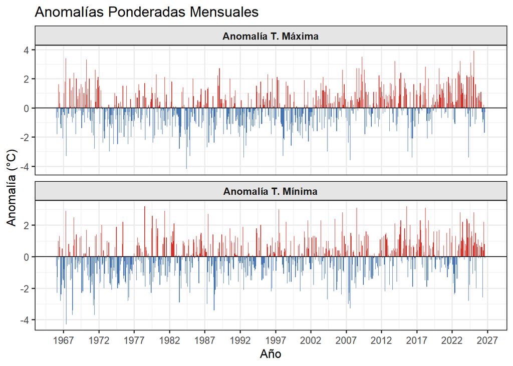

Mientras que la siguiente tabla muestra los récords mensuales desde 1966 hasta la actualidad:

**Récords Mensuales de Anomalías Ponderadas**

Valores mínimos/máximos y años de ocurrencia para cada mes

| Mes | Récord Mínimo | Récord Máximo |
| --- | --- | --- |
| Anomalía T. Máxima |  |  |
| Enero | -1.8 °C (1981) | +2.3 °C (2023) |
| Febrero | -3.3 °C (1998) | +3.9 °C (2025) |
| Marzo | -2.5 °C (1976) | +3.2 °C (2023) |
| Abril | -2.6 °C (1999) | +3.5 °C (2009) |
| Mayo | -3.4 °C (2016) | +3.4 °C (1967) |
| Junio | -4.2 °C (1984) | +2.1 °C (2024) |
| Julio | -3.4 °C (1992) | +2.7 °C (2008) |
| Agosto | -3.6 °C (2007) | +2.6 °C (2009) |
| Septiembre | -2.5 °C (1974) | +3.1 °C (2024) |
| Octubre | -3.0 °C (2015) | +2.4 °C (2014) |
| Noviembre | -2.6 °C (1992) | +2.7 °C (2008) |
| Diciembre | -3.3 °C (1984) | +3.2 °C (2013) |
| Anomalía T. Mínima |  |  |
| Enero | -1.6 °C (1971) | +1.3 °C (2022) |
| Febrero | -2.3 °C (1966) | +2.8 °C (2025) |
| Marzo | -2.8 °C (1976) | +2.8 °C (2023) |
| Abril | -3.7 °C (1968) | +3.1 °C (2018) |
| Mayo | -3.4 °C (1968) | +2.9 °C (1967) |
| Junio | -4.3 °C (1967) | +2.4 °C (2005) |
| Julio | -2.8 °C (2007) | +3.2 °C (1978) |
| Agosto | -3.3 °C (2007) | +3.2 °C (2015) |
| Septiembre | -2.4 °C (1966) | +2.3 °C (2018) |
| Octubre | -2.2 °C (1969) | +2.3 °C (2014) |
| Noviembre | -2.3 °C (1970) | +1.6 °C (2009) |
| Diciembre | -2.3 °C (1984) | +2.1 °C (2013) |

## 7.2 Evaluación de las interpolaciones

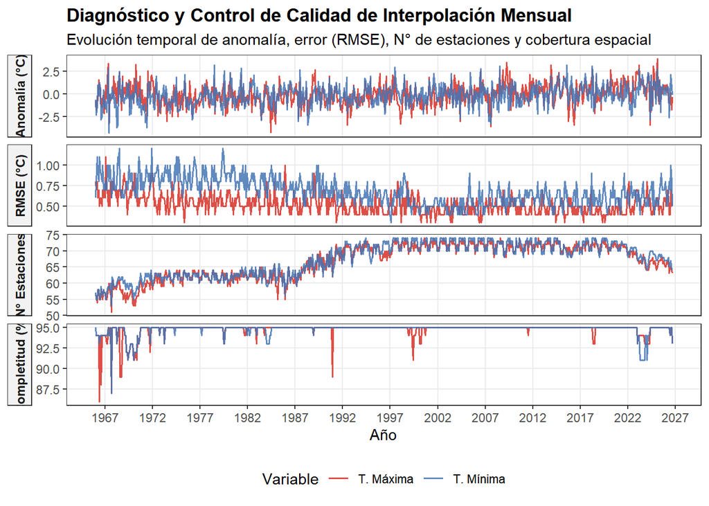

En general, el error asociado a la interpolación espacial (RMSE) es mayor para la temperatura mínima, pero a la vez se observa una disminución en la incertidumbre a medida que la cantidad de estaciones disponibles (N) aumenta. Es visible un pequeño deterioro en esta última metrica en años recientes. Por otra parte, la Completitud se mantiene estable a lo largo del tiempo luego de un inicio con un porcentaje de celdas con valores nulos que llegó a superar el 10 %.

# 8 **Versiones pasadas y futuras**

## 8.1 Cambios con respecto a la Versión 2

- El inicio del período de estudio se extendió de 1971 a 1966.
- Aumento en resolución, pasando de 1° x 1° a 0.5° x 0.5°.
- Una pequeña extensión en los límites norte y sur del área de estudio, de 0.25°.
- La determinación de celdas dentro de territorio argentino pasó de ser manual a estar definido por datos del IGN.
- Se añadió la condición de elevación (<= 2000 msnm).
- La obtención de valores reticulados se realizaba mediante interpolación lineal con el paquete `Akima`. Ahora se utiliza el método IDW con el empleo del paquete `gstat`.
- Se incluyeron 3 nuevas estaciones: Cerro Azul, Hilario Ascasubi y Pergamino (todas ellas del INTA).

## 8.2 Cambios propuestos para la Versión 4

- Extender el inicio del período de estudio a 1961.
- Añadir estaciones nuevas, con prioridad a zonas con poca densidad de estaciones.
- Se necesitan nuevos métodos para estimar valores faltantes, especialmente en estaciones en donde aún no pueden ser determinados algunos de sus valores normales mensuales.
- Versión alternativa con datos homogeneizados.

## 8.3 Desafios a largo plazo

- Extender el período de estudio hacia principios del siglo XX se dificulta debido a que un número no insignificante de las series comienzan en 1956 o en años posteriores. Parte de este déficit de datos diarios podría ser balanceado con la utilización de datos mensuales publicados en distintos documentos. También podrían añadirse estaciones cuyas series se encuentran muy afectadas por la isla de calor urbana (ICU) pero que aún así cuentan con un largo historial (Buenos Aires Obs. Central cuenta con datos desde 1906), si se pudieran aplicar métodos que remuevan los efectos de la ICU. También, cuanto más extendamos el año de inicio del estudio, más necesario será que las series sean sometidas a un proceso de homogeneización, debido a los cambios de ubicación que tuvieron lugar principalmente en las décadas de 1940 y 1950.
- Es fundamental cubrir regiones con poca densidad de estaciones. Es especialmente crítico aumentar la cobertura en la zona central del norte argentino (este de Salta, noroeste de Formosa y Chaco, norte de Santiago del Estero) y en el sudoeste de la zona de estudio (oeste de La Pampa, sur de Mendoza y San Luis, Neuquén, Rio Negro). Añadir estaciones desactivadas o sólo con datos recientes implica el desafío de obtener valores normales 1991-2020 para estas estaciones. En lo posible, el período de refencia no debería cambiar.